# Dilema 05

4 operarios, pico 6: 110 horas extra por operario frente a 80 legales; con límite, 23 semanas

# Enunciado

Una empresa de montajes ejecuta el proyecto cuyo cuadro de prelaciones, duraciones (semanas) y operarios necesarios por actividad se adjunta. La plantilla disponible es de **4 operarios** a jornada completa (40 horas semanales); no hay otros proyectos en marcha.

Tabla 1: Cuadro de datos del enunciado

| activity | predecessor | duration | resources |
| --- | --- | --- | --- |
| A | --- | 3 | 2 |
| B | --- | 2 | 1 |
| C | A,B | 1 | 1 |
| D | C | 7 | 2 |
| E | B | 6 | 3 |
| F | C,E | 5 | 3 |
| G | E | 7 | 1 |
| H | D,G | 2 | 2 |

> **De: Jefe de proyecto** El cliente quiere las 17 semanas del plan con inicios más tempranos y no vamos a contratar a nadie. Las semanas en que hagan falta más de los que somos, se hacen horas extra y ya está: se pagan y punto.

## Criterio de referencia

Las preguntas del bloque **B** se responden aplicando los criterios siguientes, tomados de la lección 19 (redactados por el curso; cada uno remite a la fuente de la que procede, que no se reproduce). La respuesta se justifica citando el criterio y la fuente, no con una opinión.

- **C7 — Cumplimiento de la ley y de las normas de seguridad.** El proyecto no puede planificarse incumpliendo una norma legal o de seguridad aunque salga más barato o más rápido; una actividad exigida por una norma no es una opción de compresión. *(cf. Código Ético del PMI, 2.3.1 y 2.2.1; ICB4, Perspectiva 3 «cumplimiento, estándares y regulaciones»; PMBOK 8, principio de calidad integrada.)*
- **Norma — jornada ordinaria máxima: 40 horas semanales de trabajo efectivo de promedio en cómputo anual** *(Estatuto de los Trabajadores, art. 34.1.)*
- **Norma — máximo de horas extraordinarias: 80 por trabajador y año, sin contar las compensadas con descanso en los cuatro meses siguientes** *(Estatuto de los Trabajadores (RDL 2/2015), art. 35.2.)*

Responda a las preguntas: A (cálculo), B (criterio) y C (deliberación).

1. 1. Dibuje el diagrama de cargas con inicios más tempranos y obtenga, semana a semana, el exceso de operarios sobre los 4 disponibles. Traduzca el exceso a horas extraordinarias por operario en el año (reparto uniforme entre la plantilla).

2. 1. Calcule la duración del proyecto si se respeta el límite de 4 operarios (asignación con límite) y, alternativamente, cuántos operarios haría falta contratar para cumplir las semanas del plan sin horas extra.

3. 2. Según el criterio y la norma de referencia, ¿puede ejecutarse el plan del jefe de proyecto? Justifique con la cifra.

4. 3. ¿Qué propone al jefe de proyecto y al cliente? Aplique la rúbrica de la lección.

# Resolución

Cálculo de los tiempos tempranos y tardíos de los sucesos y de las holguras totales paso a paso. El primer paso muestra el grafo resuelto; a partir del siguiente se calcula desde el principio (avance con los botones):

[figure not shown]

paso 0 de 29

[figure not shown]

Figura 1: Grafo PERT del proyecto

## Apartado 1

1. 1. Dibuje el diagrama de cargas con inicios más tempranos y obtenga, semana a semana, el exceso de operarios sobre los 4 disponibles. Traduzca el exceso a horas extraordinarias por operario en el año (reparto uniforme entre la plantilla).

[figure not shown]

Figura 2: Gantt con inicios más tempranos y carga de operarios

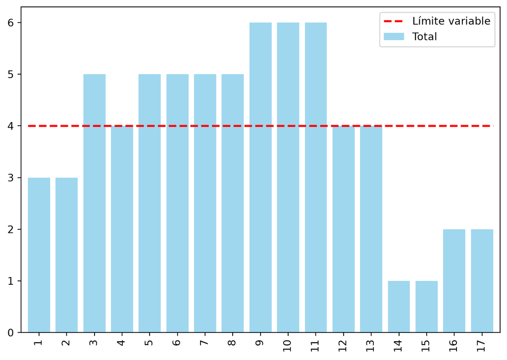

Figura 3: Diagrama de cargas frente a la plantilla disponible

La tabla siguiente da, semana a semana, los operarios necesarios con inicios más tempranos (fila «Total» del Gantt), el exceso sobre la plantilla, exceso = máx(0, necesarios − 4), las horas extra que ese exceso supone (exceso × 40 h) y su reparto uniforme entre los 4 operarios (horas extra / 4).

Tabla 2: Exceso de operarios y horas extraordinarias semana a semana

|  | 1 | 2 | 3 | 4 | 5 | 6 | 7 | 8 | 9 | 10 | 11 | 12 | 13 | 14 | 15 | 16 | 17 | Total |
| --- | --- | --- | --- | --- | --- | --- | --- | --- | --- | --- | --- | --- | --- | --- | --- | --- | --- | --- |
| operarios necesarios | 3 | 3 | 5 | 4 | 5 | 5 | 5 | 5 | 6 | 6 | 6 | 4 | 4 | 1 | 1 | 2 | 2 | 67 |
| exceso sobre la plantilla | 0 | 0 | 1 | 0 | 1 | 1 | 1 | 1 | 2 | 2 | 2 | 0 | 0 | 0 | 0 | 0 | 0 | 11 |
| horas extra de la semana | 0 | 0 | 40 | 0 | 40 | 40 | 40 | 40 | 80 | 80 | 80 | 0 | 0 | 0 | 0 | 0 | 0 | 440 |
| horas extra por operario | 0 | 0 | 10 | 0 | 10 | 10 | 10 | 10 | 20 | 20 | 20 | 0 | 0 | 0 | 0 | 0 | 0 | 110 |

Pico de **6** operarios frente a 4; hay exceso en 8 semanas (semanas 3 y 5–11).

- Exceso total: 1 + 1 + 1 + 1 + 1 + 2 + 2 + 2 = **11 operario-semanas**.

- Horas extra: 11 × 40 h = **440 h**.

- Por operario (reparto uniforme): 440 / 4 = **110 h** en el año (el proyecto dura 17 semanas, menos de un año).

- En la peor semana (la 9) cada operario trabajaría 40 + 20 = 60 h.

**Respuesta.** El plan exige **110 horas extraordinarias por operario** en el año, más que las 80 que permite la ley.

## Apartado 2

2. 1. Calcule la duración del proyecto si se respeta el límite de 4 operarios (asignación con límite) y, alternativamente, cuántos operarios haría falta contratar para cumplir las semanas del plan sin horas extra.

**Con el límite de 4 operarios** (asignación: cada semana entran las actividades por orden de prioridad mientras caben en la plantilla; las demás esperan) el proyecto dura **23** semanas, 6 semanas más que las 17 del plan (Gantt siguiente).

**Para cumplir las 17 semanas sin horas extra** hay que cubrir el exceso con personal contratado: como máximo 6 − 4 = **2** operarios a la vez, y no todas las semanas: 1 operario en las semanas 3 y 5–8; 2 operarios en las semanas 9–11, en total 11 operario-semanas de refuerzo.

Combinación legal: las 80 h por operario permiten 80 × 4 = 320 h = 8 operario-semanas en horas extra; el resto, 3 operario-semanas, con refuerzo.

**Respuesta.** Con el límite de 4 operarios el proyecto dura 23 semanas; para cumplir 17 sin horas extra hay que contratar 2 operarios en el pico (11 operario-semanas en total).

[figure not shown]

Figura 4: Gantt con asignación limitada a la plantilla

## Apartado 3

3. 2. Según el criterio y la norma de referencia, ¿puede ejecutarse el plan del jefe de proyecto? Justifique con la cifra.

**Criterio C7 y norma.** El Estatuto de los Trabajadores limita las horas extraordinarias a 80 por trabajador y año (art. 35.2), sin contar las compensadas con descanso, y la jornada ordinaria a 40 horas semanales de promedio (art. 34.1). El plan del jefe de proyecto exige 110 h por operario, +30 h sobre el máximo, con semanas de 60 h. Según C7, un plan que incumple una norma no es una opción de planificación, por mucho que las horas «se paguen»: pagar no convierte en legal lo que la ley limita.

**Respuesta.** **No puede ejecutarse**: 110 h > 80 h por operario y año, salvo que el exceso se compense con descanso (lo que alargaría el proyecto igualmente).

**1. El máximo de horas extraordinarias por trabajador y año fijado por el Estatuto de los Trabajadores es…**

- ✅ 80

- ◻️ 40

- ◻️ 120

- ◻️ no hay máximo si se pagan

*Art. 35.2 ET: 80 horas al año, sin contar las compensadas con descanso.*

**2. Un plan que exige más horas extra de las legales…**

- ✅ no es una opción: se descarta por C7

- ◻️ es válido si el cliente lo acepta

- ◻️ es válido si se pagan

- ◻️ depende del jefe de proyecto

*El cumplimiento legal es condición previa, no un coste más en la tabla.*

**3. Para cumplir el plazo sin horas extra la alternativa objetiva es…**

- ✅ contratar operarios para las semanas de pico o aceptar la duración con límite

- ◻️ reducir la calidad

- ◻️ no hacer el diagrama de cargas

- ◻️ cambiar las prelaciones

*El diagrama de cargas da el pico y la asignación con límite da la nueva duración.*

## Apartado 4

4. 3. ¿Qué propone al jefe de proyecto y al cliente? Aplique la rúbrica de la lección.

La pregunta del bloque C es abierta: no tiene una respuesta única y se evalúa el **procedimiento**: (1) identificar a todos los afectados y qué pierde o gana cada uno; (2) formular al menos dos alternativas además de la que se propone en el enunciado; (3) someter cada alternativa a las tres pruebas —legalidad (¿cumple la norma?), publicidad (¿la defendería si se hiciera pública?) y reversibilidad (¿la aceptaría en el papel del afectado?)—; (4) decidir y redactar la comunicación con las cifras del bloque A. Una respuesta que sólo opina, sin cifras ni alternativas, no supera la rúbrica.

**La rúbrica aplicada a este caso** (lo que debe contener una respuesta que la supere):

*(1) Afectados y qué gana o pierde cada uno:*

- **Operarios**: 110 h extra cada uno y semanas de hasta 60 h: salud, seguridad y descanso

- **Cliente**: quiere 17 semanas; con la plantilla serían 23

- **Empresa**: ahorra la contratación de 11 operario-semanas a cambio de un incumplimiento sancionable y de un riesgo de accidentes

- **Jefe de proyecto**: cumple el plazo «sobre el papel» con un plan que no puede firmar

*(2) y (3) Alternativas y las tres pruebas:*

| alternativa | legalidad | publicidad | reversibilidad |
| --- | --- | --- | --- |
| Horas extra sin límite: 110 h por operario (propuesta) | no: supera las 80 h del art. 35.2 | no | no: ningún operario aceptaría esas semanas si pudiera elegir |
| Aceptar 23 semanas con la plantilla | sí | sí | sí, si el cliente lo acepta informado |
| Contratar el refuerzo: 11 operario-semanas (hasta 2 a la vez) | sí | sí | sí |
| Combinar: 8 operario-semanas en horas extra (≤ 80 h por operario) y el resto con refuerzo | sí | sí | sí |

*(4) Decisión y comunicación* (un camino defendible, no el único): al jefe de proyecto, la tabla de opciones con su coste y su fecha (23 semanas con la plantilla; 17 contratando 11 operario-semanas; o la combinación dentro de las 80 h); al cliente, la opción elegida con su precio y su fecha. Lo que no se le cuenta es que el plazo «se consigue» incumpliendo la ley, porque no está en la tabla.